# FilmReview

Yakovlev D.M.

2024-09-05

```r
library("readxl")
```

## 2. Считывание и просмотр

```r
library("tidyverse")
```

```r
panel.hist <- function(x, ...)
{
    usr <- par("usr")
    par(usr = c(usr[1:2], 0, 1.5) )
    h <- hist(x, plot = FALSE)
    breaks <- h$breaks; nB <- length(breaks)
    y <- h$counts; y <- y/max(y)
    rect(breaks[-nB], 0, breaks[-1], y, col = "cyan", ...)
}
panel.cor <- function(x, y, digits = 2, prefix = "", cex.cor, ...)
{
    par(usr = c(0, 1, 0, 1))
    r <- abs(cor(x, y))
    txt <- format(c(r, 0.123456789), digits = digits)[1]
    txt <- paste0(prefix, txt)
    if(missing(cex.cor)) cex.cor <- 0.8/strwidth(txt)
    text(0.5, 0.5, txt, cex = cex.cor * r)
}
```

```r
df<-read_excel("my101descr/MY101.xls")
head(df)
```

```
## # A tibble: 6 × 202
##   НЕВЕРОТН ТЕЛОХРАН КАВКАЗСК ПТЫЙ_ЭЛЕ ТЕРМИНАТ КРЕПКИЙ ПОЛИЦ_АК ЧУЖИЕ КРОКОДИЛ
##      <dbl>    <dbl>    <dbl>    <dbl>    <dbl>   <dbl>    <dbl> <dbl>    <dbl>
## 1        5        6        8     11.7      8.7       8      8       5        3
## 2        7        7        7     10        3         9      6.2    12        2
## 3       12        7        6     10        7         8      7       6        7
## 4        7        8       12      7       12        11      9      12       10
## 5        5        9        2     11        8         6      2       3        4
## 6        9        8        8     11        7        10      8      10       11
## # ℹ 193 more variables: ЗДРАВСТВ <dbl>, ИРОНИ_СУ <dbl>, КРАСОТКА <dbl>,
## #   МАТРИЦА <dbl>, ТИТАНИК <dbl>, К_9 <dbl>, НАЗАД_В <dbl>, САМА_ОБА <dbl>,
## #   БЛИЗНЕЦЫ <dbl>, СОБАЧЬЕ <dbl>, СОБАКА_Б <dbl>, МЕСТО_ВС <dbl>, ГОРЕЦ <dbl>,
## #   СЛУЖЕБНЫ <dbl>, КРИМИНАЛ <dbl>, ОС_РЫБ <dbl>, ОС_ОХОТЫ <dbl>,
## #   ДЕСТЬ_НЕ <dbl>, ТЕРМИНA2 <dbl>, ВОКЗАЛ_Д <dbl>, ГЕНИЙ <dbl>,
## #   ИВАН_ВАС <dbl>, РОККИ <dbl>, ОДИН_ДОМ <dbl>, САМОГОНЩ <dbl>,
## #   ОБЫКНОВЕ <dbl>, В_БОЙ_ИД <dbl>, ПАРК_ЮРС <dbl>, МОСКВА_С <dbl>, …
```

# Создание справочника имён

```r
name_ref <- read_excel("my101descr/iqrate_description.xlsx", col_names = FALSE)
name_ref <- str_split_fixed(name_ref$...2, " ", 2)|>
  as.data.frame()|>setNames(c("id", "names"))|>rmarkdown::paged_table()
name_ref$id[140:nrow(name_ref)]<-c(140:nrow(name_ref))
name_ref$names[c(139,140,142)] <- c("Возраст", "STAT_1", "STAT_2")
name_ref
```

| id | names |
| --- | --- |
| 1 | Невероятные приключения итальянцев в России |
| 2 | Телохранитель |
| 3 | Кавказская пленница или Новые приключения Шурика |
| 4 | Пятый элемент |
| 5 | Терминатор |
| 6 | Крепкий орешек |
| 7 | Полицейская академия |
| 8 | Чужие |
| 9 | Крокодил Данди |
| 10 | Здравствуйте, я ваша тетя! |

[output cut: 192 more lines]

```r
colnames(df) <- name_ref$id
df
```

```
## # A tibble: 3,500 × 202
##      `1`   `2`   `3`   `4`   `5`   `6`   `7`   `8`   `9`  `10`  `11`  `12`  `13`
##    <dbl> <dbl> <dbl> <dbl> <dbl> <dbl> <dbl> <dbl> <dbl> <dbl> <dbl> <dbl> <dbl>
##  1   5       6     8  11.7   8.7     8   8       5   3       8     9   8.8   7.7
##  2   7       7     7  10     3       9   6.2    12   2      11    12   8    11
##  3  12       7     6  10     7       8   7       6   7       6     6   6    10
##  4   7       8    12   7    12      11   9      12  10       6    12   6     9
##  5   5       9     2  11     8       6   2       3   4       5     6   6    10
##  6   9       8     8  11     7      10   8      10  11       9     8   7    11
##  7   7      10     7   8     8      10   8       6   9       8     8   8     8
##  8  12       5     8   4     8      10   3       2   9      12     5   6    10
##  9   9.3     6    10  12     9.5     7   2.7     6   8.7     9     7   8.1   9.3
## 10   7       6     8   9     9       9   8       9   6       7     7   7    11
## # ℹ 3,490 more rows
## # ℹ 189 more variables: `14` <dbl>, `15` <dbl>, `16` <dbl>, `17` <dbl>,
## #   `18` <dbl>, `19` <dbl>, `20` <dbl>, `21` <dbl>, `22` <dbl>, `23` <dbl>,
## #   `24` <dbl>, `25` <dbl>, `26` <dbl>, `27` <dbl>, `28` <dbl>, `29` <dbl>,
## #   `30` <dbl>, `31` <dbl>, `32` <dbl>, `33` <dbl>, `34` <dbl>, `35` <dbl>,
## #   `36` <dbl>, `37` <dbl>, `38` <dbl>, `39` <dbl>, `40` <dbl>, `41` <dbl>,
## #   `42` <dbl>, `43` <dbl>, `44` <dbl>, `45` <dbl>, `46` <dbl>, `47` <dbl>, …
```

```r
name_ref
```

| id | names |
| --- | --- |
| 1 | Невероятные приключения итальянцев в России |
| 2 | Телохранитель |
| 3 | Кавказская пленница или Новые приключения Шурика |
| 4 | Пятый элемент |
| 5 | Терминатор |
| 6 | Крепкий орешек |
| 7 | Полицейская академия |
| 8 | Чужие |
| 9 | Крокодил Данди |
| 10 | Здравствуйте, я ваша тетя! |

[output cut: 192 more lines]

```r
df_names <- df|>setNames(name_ref$names)
df_names$Пол[df_names$Пол==1] <- "Муж"
df_names$Пол[df_names$Пол==2] <- "Жен"
df_names$Пол[is.na(df_names$Пол)] <- "Неизв"
df_names
```

```
## # A tibble: 3,500 × 202
##     Невероятные приключения итальянцев…¹ ` Телохранитель`  Кавказская пленница…²
##                                    <dbl>            <dbl>                  <dbl>
##  1                                   5                  6                      8
##  2                                   7                  7                      7
##  3                                  12                  7                      6
##  4                                   7                  8                     12
##  5                                   5                  9                      2
##  6                                   9                  8                      8
##  7                                   7                 10                      7
##  8                                  12                  5                      8
##  9                                   9.3                6                     10
## 10                                   7                  6                      8
## # ℹ 3,490 more rows
## # ℹ abbreviated names: ¹` Невероятные приключения итальянцев в России`,
## #   ²` Кавказская пленница или Новые приключения Шурика`
## # ℹ 199 more variables: ` Пятый элемент` <dbl>, ` Терминатор` <dbl>,
## #   ` Крепкий орешек` <dbl>, ` Полицейская академия` <dbl>, ` Чужие` <dbl>,
## #   ` Крокодил Данди` <dbl>, ` Здравствуйте, я ваша тетя!` <dbl>,
## #   ` Ирония судьбы или с легким паром` <dbl>, ` Красотка` <dbl>, …
```

```r
name_ref
```

| id | names |
| --- | --- |
| 1 | Невероятные приключения итальянцев в России |
| 2 | Телохранитель |
| 3 | Кавказская пленница или Новые приключения Шурика |
| 4 | Пятый элемент |
| 5 | Терминатор |
| 6 | Крепкий орешек |
| 7 | Полицейская академия |
| 8 | Чужие |
| 9 | Крокодил Данди |
| 10 | Здравствуйте, я ваша тетя! |

[output cut: 192 more lines]

# 0. Общая сводка по таблице

```r
df_names
```

```
## # A tibble: 3,500 × 202
##     Невероятные приключения итальянцев…¹ ` Телохранитель`  Кавказская пленница…²
##                                    <dbl>            <dbl>                  <dbl>
##  1                                   5                  6                      8
##  2                                   7                  7                      7
##  3                                  12                  7                      6
##  4                                   7                  8                     12
##  5                                   5                  9                      2
##  6                                   9                  8                      8
##  7                                   7                 10                      7
##  8                                  12                  5                      8
##  9                                   9.3                6                     10
## 10                                   7                  6                      8
## # ℹ 3,490 more rows
## # ℹ abbreviated names: ¹` Невероятные приключения итальянцев в России`,
## #   ²` Кавказская пленница или Новые приключения Шурика`
## # ℹ 199 more variables: ` Пятый элемент` <dbl>, ` Терминатор` <dbl>,
## #   ` Крепкий орешек` <dbl>, ` Полицейская академия` <dbl>, ` Чужие` <dbl>,
## #   ` Крокодил Данди` <dbl>, ` Здравствуйте, я ваша тетя!` <dbl>,
## #   ` Ирония судьбы или с легким паром` <dbl>, ` Красотка` <dbl>, …
```

```r
name_ref
```

| id | names |
| --- | --- |
| 1 | Невероятные приключения итальянцев в России |
| 2 | Телохранитель |
| 3 | Кавказская пленница или Новые приключения Шурика |
| 4 | Пятый элемент |
| 5 | Терминатор |
| 6 | Крепкий орешек |
| 7 | Полицейская академия |
| 8 | Чужие |
| 9 | Крокодил Данди |
| 10 | Здравствуйте, я ваша тетя! |

[output cut: 192 more lines]

```r
nrow(df_names)
```

```
## [1] 3500
```

```r
ncol(df_names)
```

```
## [1] 202
```

Отсюда, 3500 участников и 202 признака.

Теперь вопрос, какая часть таблицы содержит NA?

```r
df_names|>apply(2, function(x) sum(is.na(x)))|>sum()/nrow(df_names)/ncol(df_names)
```

```
## [1] 0.6025941
```

При первом рассмотрении выясняется, что некоторые столбцы группируются по тестам и другим опросам, поэтому вместо одного NA получаем несколько.

```r
library("ggplot2")
```

# 1. Что-то с возрастом

```r
summary(df_names$Возраст)
```

```
##    Min. 1st Qu.  Median    Mean 3rd Qu.    Max.    NA's
##   12.00   22.00   25.00   26.33   29.00   60.00    1433
```

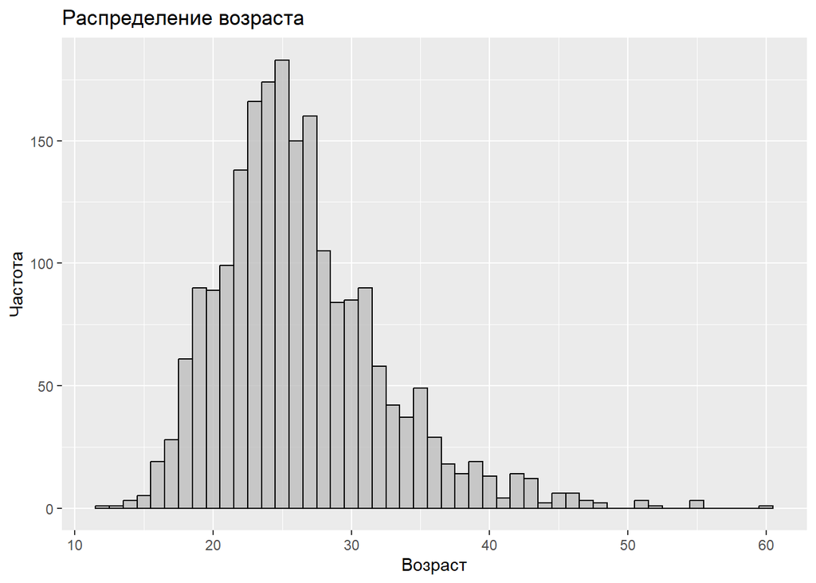

```r
ggplot(df_names, aes(x = Возраст))+
  geom_histogram(binwidth = 1, fill = "grey", color = "black", alpha = 0.8) +
  labs(title = "Распределение возраста", x = "Возраст", y = "Частота")
```

Рассмотрим предрасположенность к фильмам в зависимости от даты выхода. Поступим таким образом. Возьмём несколько фильмов с разной датой выхода, разобъём людей на возрастные группы и проверим, как оценки фильмов коррелируют с возрастом

Перед этим посмотрим, какие возраста имеются.

```r
df_names|>select(c(139))|>group_by(Возраст)|>summarize(ВозЧисло=n())
```

```
## # A tibble: 42 × 2
##    Возраст ВозЧисло
##      <dbl>    <int>
##  1      12        1
##  2      13        1
##  3      14        3
##  4      15        5
##  5      16       19
##  6      17       28
##  7      18       61
##  8      19       90
##  9      20       89
## 10      21       99
## # ℹ 32 more rows
```

От 12 до 60. Сформируем три возрастные группы: Поколение Z (12-27), Миллениалы (28-43), Поколение X (44-60).

```r
df_age<-df_names|>filter(!is.na(Возраст))|>mutate(Поколение=case_when(Возраст<=27~"Gen Z", Возраст>=28&Возраст<=43~"Millennials", Возраст>=44~"Gen X"), .after=Возраст)
df_age
```

```
## # A tibble: 2,067 × 203
##     Невероятные приключения итальянцев…¹ ` Телохранитель`  Кавказская пленница…²
##                                    <dbl>            <dbl>                  <dbl>
##  1                                   5                  6                      8
##  2                                   7                  7                      7
##  3                                  12                  7                      6
##  4                                   7                  8                     12
##  5                                   5                  9                      2
##  6                                   9                  8                      8
##  7                                   7                 10                      7
##  8                                  12                  5                      8
##  9                                   9.3                6                     10
## 10                                   7                  6                      8
## # ℹ 2,057 more rows
## # ℹ abbreviated names: ¹` Невероятные приключения итальянцев в России`,
## #   ²` Кавказская пленница или Новые приключения Шурика`
## # ℹ 200 more variables: ` Пятый элемент` <dbl>, ` Терминатор` <dbl>,
## #   ` Крепкий орешек` <dbl>, ` Полицейская академия` <dbl>, ` Чужие` <dbl>,
## #   ` Крокодил Данди` <dbl>, ` Здравствуйте, я ваша тетя!` <dbl>,
## #   ` Ирония судьбы или с легким паром` <dbl>, ` Красотка` <dbl>, …
```

Невероятные приключения итальянцев в России (1974, Gen X), Телохранитель (1992, Millennial), Армагеддон (1998, Gen Z)

```r
name_ref
```

| id | names |
| --- | --- |
| 1 | Невероятные приключения итальянцев в России |
| 2 | Телохранитель |
| 3 | Кавказская пленница или Новые приключения Шурика |
| 4 | Пятый элемент |
| 5 | Терминатор |
| 6 | Крепкий орешек |
| 7 | Полицейская академия |
| 8 | Чужие |
| 9 | Крокодил Данди |
| 10 | Здравствуйте, я ваша тетя! |

[output cut: 192 more lines]

```r
library("GGally")
```

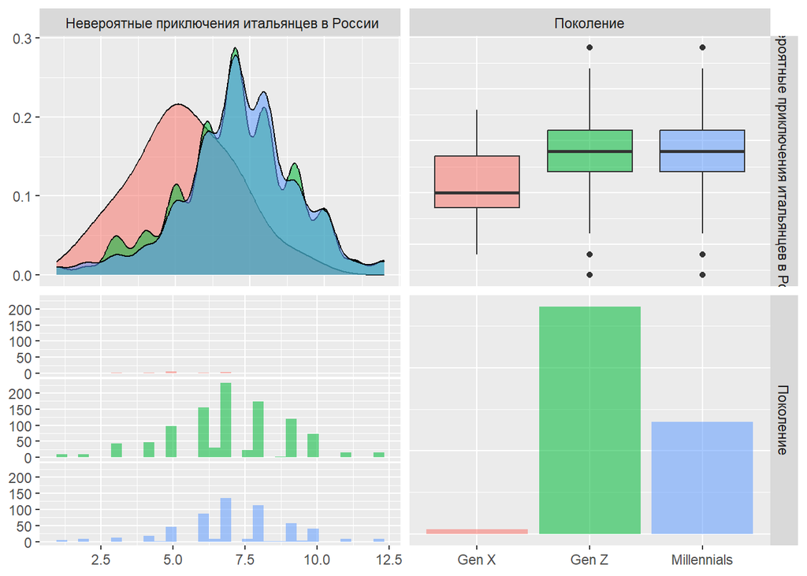

```r
ggpairs(df_age, columns = c(1, 140), aes(color = Поколение, alpha = 0.5),
        upper = list(continuous = wrap("cor", size = 2.5)))
```

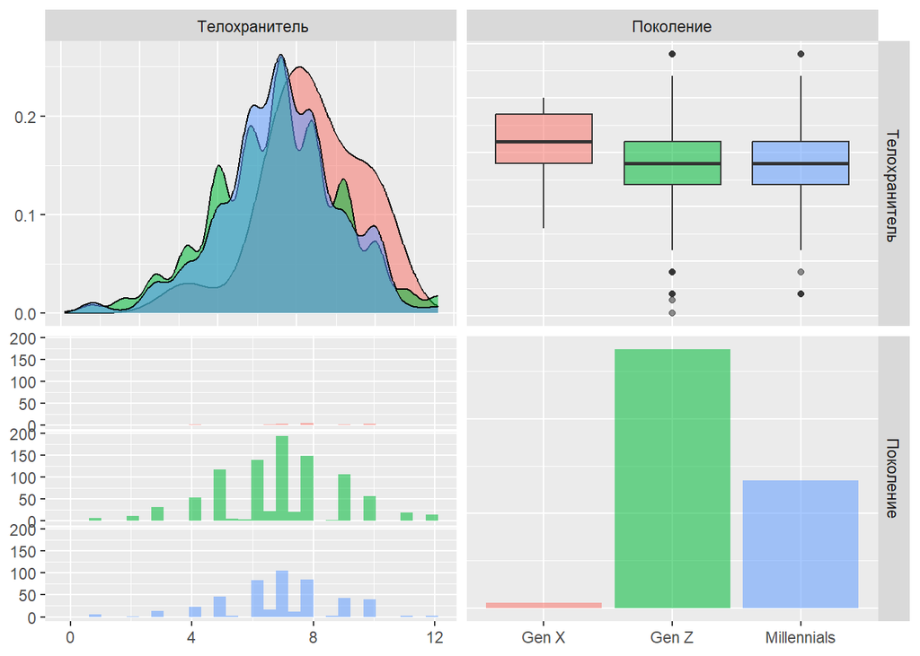

```r
ggpairs(df_age, columns = c(2, 140), aes(color = Поколение, alpha = 0.5),
        upper = list(continuous = wrap("cor", size = 2.5)))
```

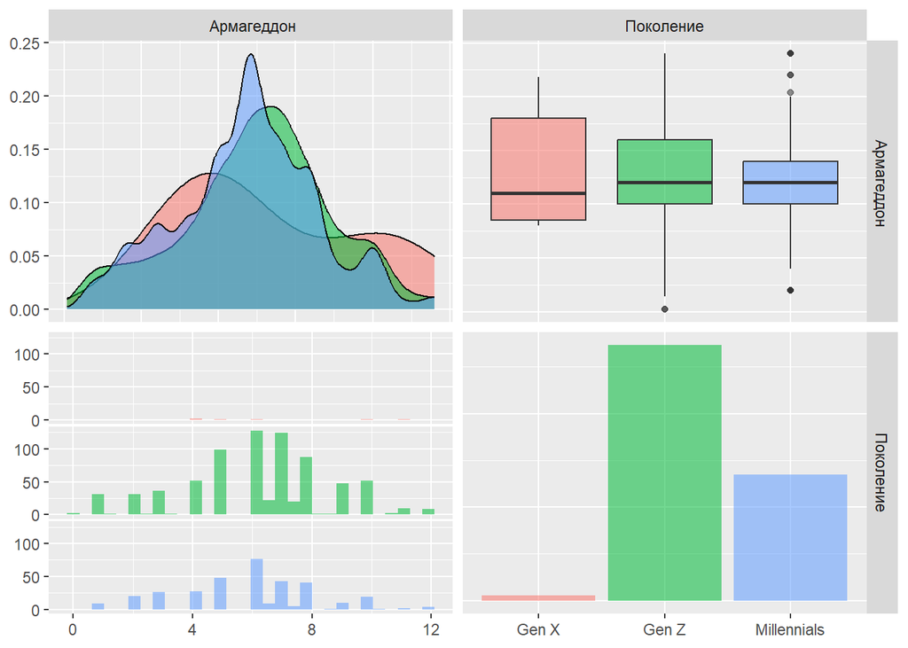

```r
ggpairs(df_age, columns = c(50, 140), aes(color = Поколение, alpha = 0.5),
        upper = list(continuous = wrap("cor", size = 2.5)))
```

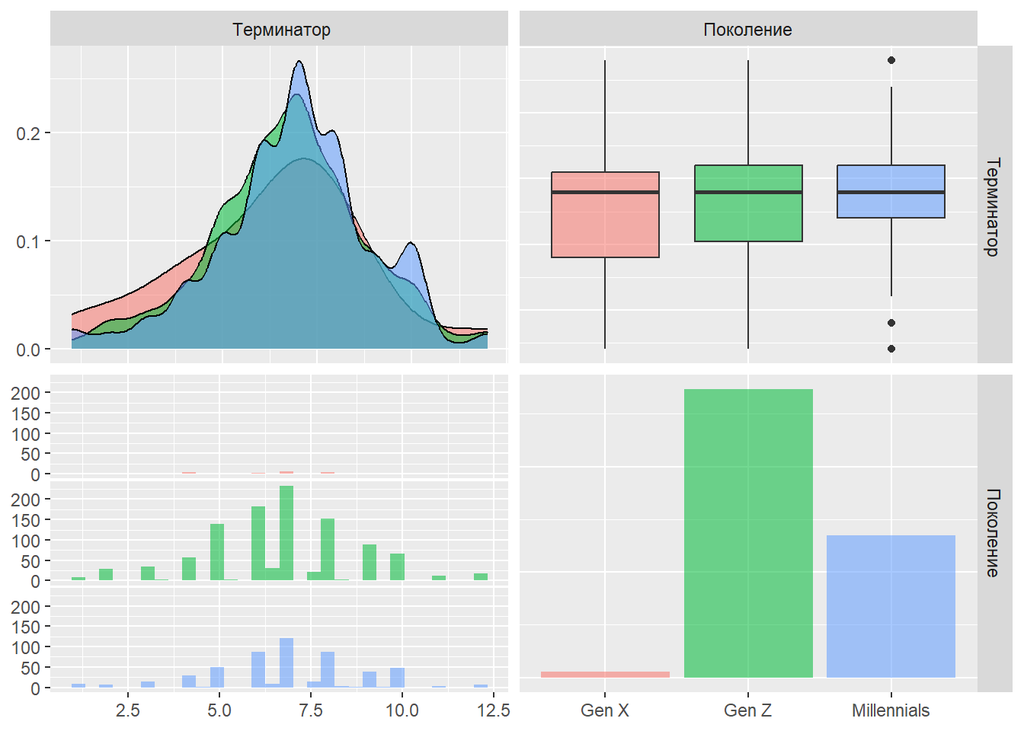

```r
ggpairs(df_age, columns = c(5, 140), aes(color = Поколение, alpha = 0.5),
        upper = list(continuous = wrap("cor", size = 2.5)))
```

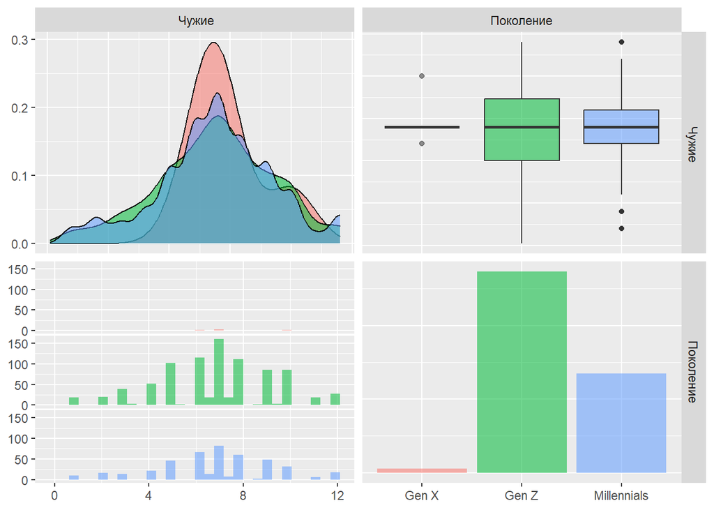

```r
ggpairs(df_age, columns = c(8, 140), aes(color = Поколение, alpha = 0.5),
        upper = list(continuous = wrap("cor", size = 2.5)))
```

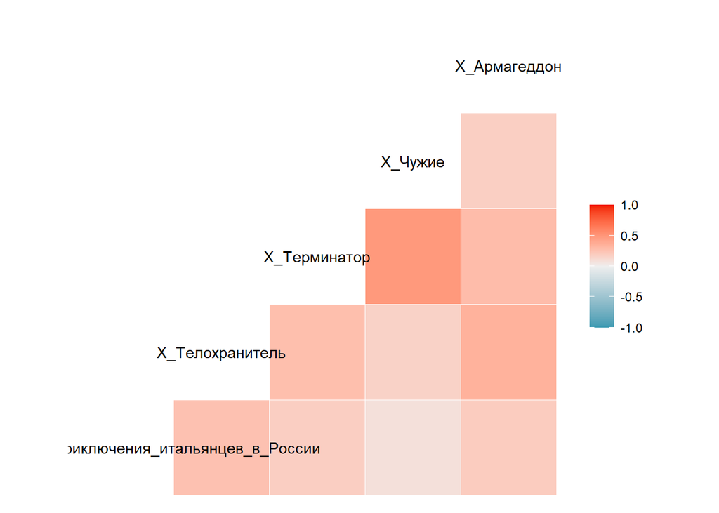

```r
ggcorr(df_age[, c(1, 2, 5, 8, 50)])
```

# 2. Что-то с IQ

```r
summary(df_names$IQ)
```

```
##    Min. 1st Qu.  Median    Mean 3rd Qu.    Max.    NA's
##    90.0   115.0   125.0   125.2   135.0   177.5    2535
```

Что интересного можно проанализировать на основе IQ? Например, уровень образования и дохода

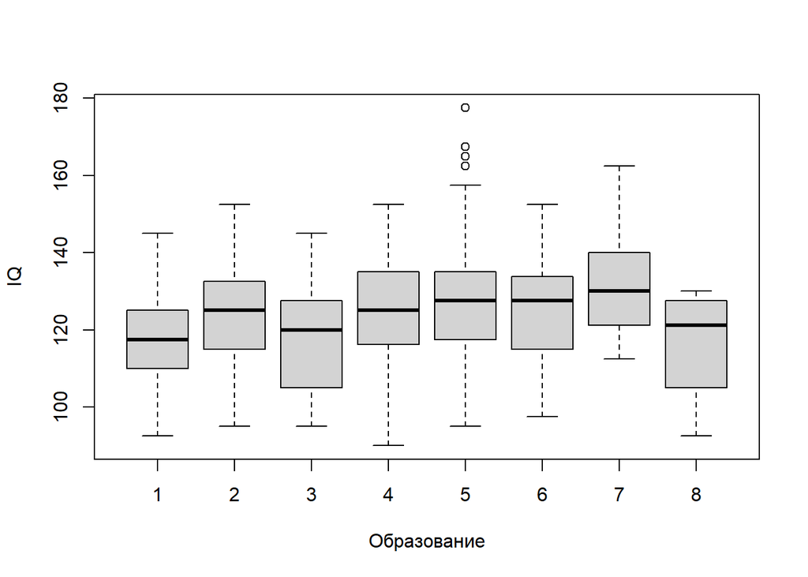

```r
boxplot(df_names$IQ~df_names$Обpазование, xlab="Образование", ylab="IQ")
```

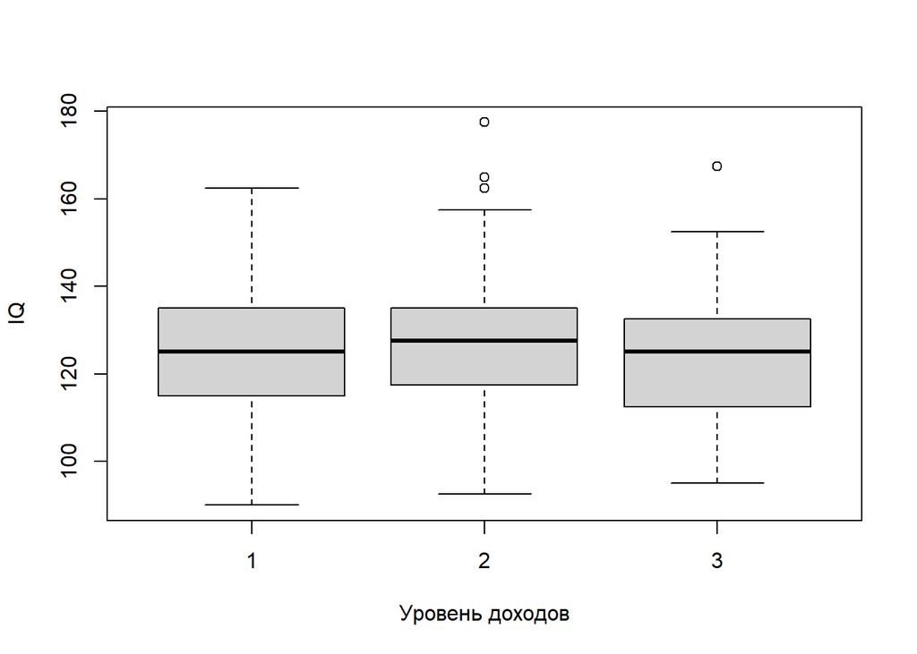

```r
boxplot(df_names$IQ~df_names$`Уpовень доходов`, xlab="Уровень доходов", ylab="IQ")
```

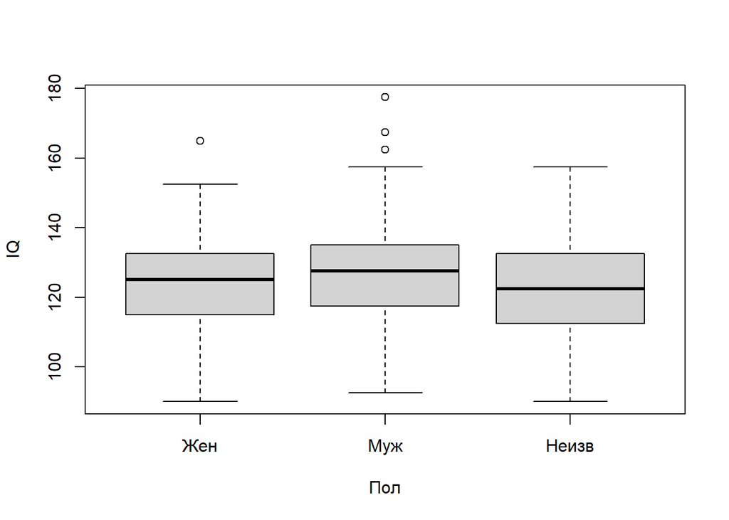

```r
boxplot(df_names$IQ~df_names$Пол, xlab="Пол", ylab="IQ")
```

Не понятно, какие категории у образования. С доходами тоже самое.

Ещё интересно, влияет ли IQ на оценки фильмов. Для этого разобъём IQ по группам и для каждого индивида посчитаем среднюю оценку фильмов и построим box with whiskers

```r
table(df_names$IQ)
```

```
##
##    90  92.5    95  97.5   100 102.5   105 107.5   110 112.5   115 117.5   120
##     3    10    11     7    15    17    22    27    36    49    53    63    63
## 122.5   125 127.5   130 132.5   135 137.5   140 142.5   145 147.5   150 152.5
##    63    63    62    68    72    61    46    41    31    30    16    14     9
##   155 157.5 162.5   165 167.5 177.5
##     2     5     3     1     1     1
```

```r
df_IQ<-df_names|>mutate(IQ_group=case_when(IQ<=120~"90-120", IQ>120&IQ<=140~"121-140", IQ>140~"141-180"), mean_movie_score=rowMeans(df_names[,1:101], na.rm=TRUE), .after=IQ)
df_IQ|>select(IQ, IQ_group, mean_movie_score)
```

```
## # A tibble: 3,500 × 3
##       IQ IQ_group mean_movie_score
##    <dbl> <chr>               <dbl>
##  1  112. 90-120               7.04
##  2  135  121-140              7.62
##  3  162. 141-180              7.12
##  4   NA  <NA>                 9.23
##  5  128. 121-140              6.52
##  6  130  121-140              8.61
##  7  110  90-120               7.54
##  8  122. 121-140              7.80
##  9  152. 141-180              7.70
## 10  128. 121-140              7.24
## # ℹ 3,490 more rows
```

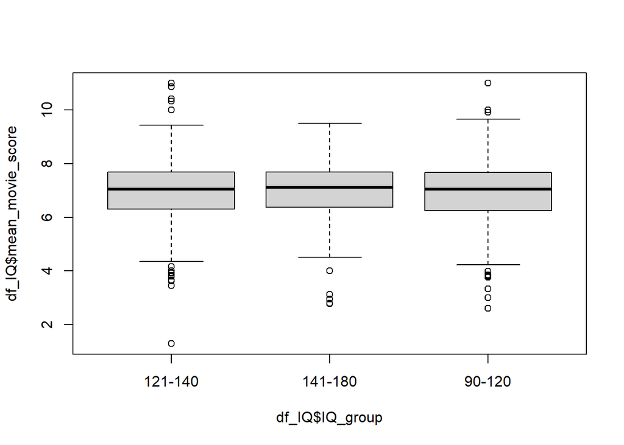

```r
boxplot(df_IQ$mean_movie_score~df_IQ$IQ_group)
```

Результаты схожи. За исключением аутсайдеров, IQ мало влияет на среднюю оценку (в таких группах).

Попробуем то же самое, но для конкретных фильмов.

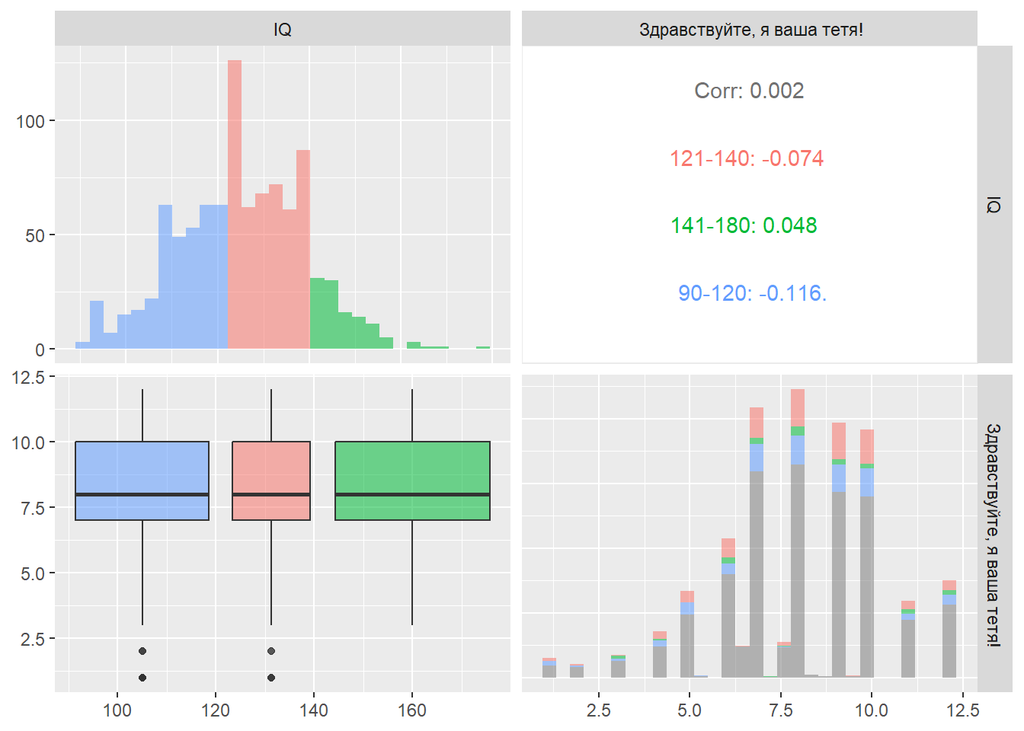

```r
ggpairs(df_IQ, columns = c(124, 10), aes(color = IQ_group, alpha = 0.5), diag=list(continuous="barDiag"), lower = list(continuous="box_no_facet"))
```

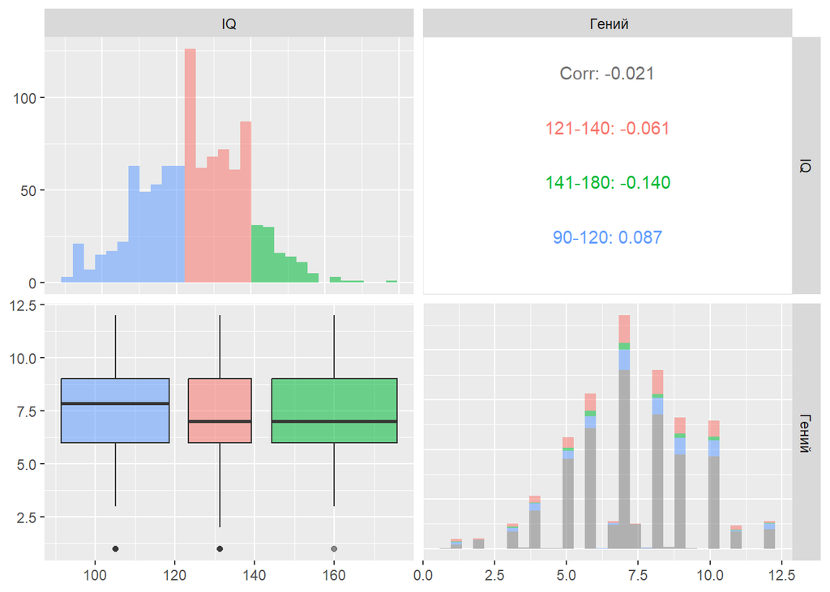

```r
ggpairs(df_IQ, columns = c(124, 30), aes(color = IQ_group, alpha = 0.5), diag=list(continuous="barDiag"), lower = list(continuous="box_no_facet"))
```

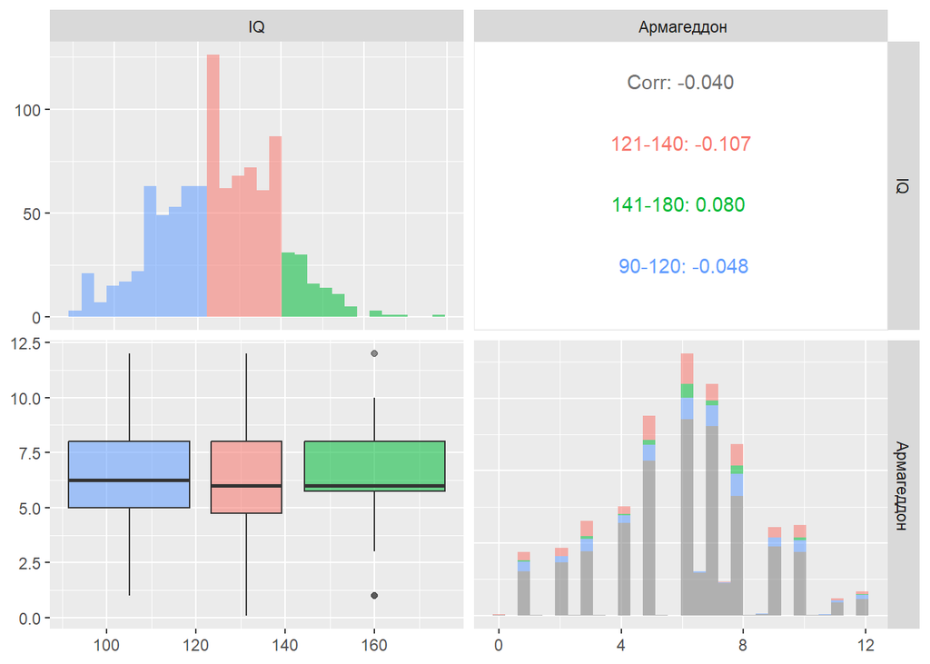

```r
ggpairs(df_IQ, columns = c(124, 50), aes(color = IQ_group, alpha = 0.5), diag=list(continuous="barDiag"), lower = list(continuous="box_no_facet"))
```

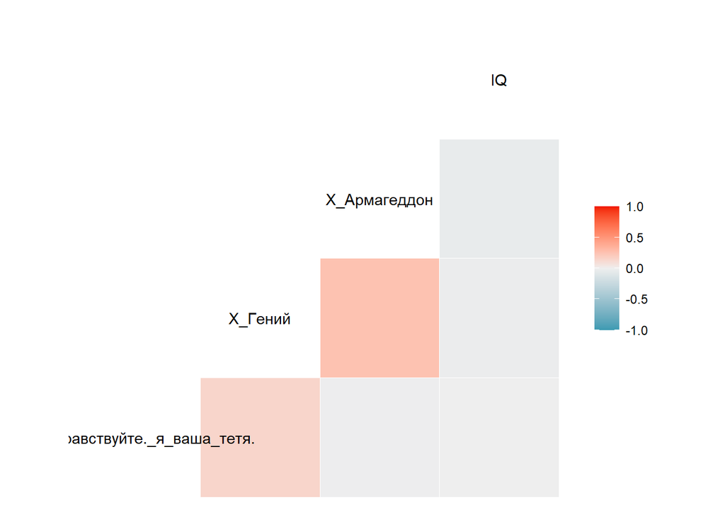

```r
ggcorr(df_names[, c(10, 30, 50, 124)])
```

Можно заметить, что для фильма “Гений” люди с IQ “90-120” оценили в среднем фильм лучше, чем другие группы.

```r
name_ref
```

| id | names |
| --- | --- |
| 1 | Невероятные приключения итальянцев в России |
| 2 | Телохранитель |
| 3 | Кавказская пленница или Новые приключения Шурика |
| 4 | Пятый элемент |
| 5 | Терминатор |
| 6 | Крепкий орешек |
| 7 | Полицейская академия |
| 8 | Чужие |
| 9 | Крокодил Данди |
| 10 | Здравствуйте, я ваша тетя! |

[output cut: 192 more lines]

# 3. Что-то с полом

Изначально в таблице были 1, 2 и NA. Они были заменены на 1 - Мужчины, 2 - Женщины, NA - Неизвестно

```r
table(df_names$Пол)
```

```
##
##   Жен   Муж Неизв
##  1235  1514   751
```

Посмотрим на возраст.

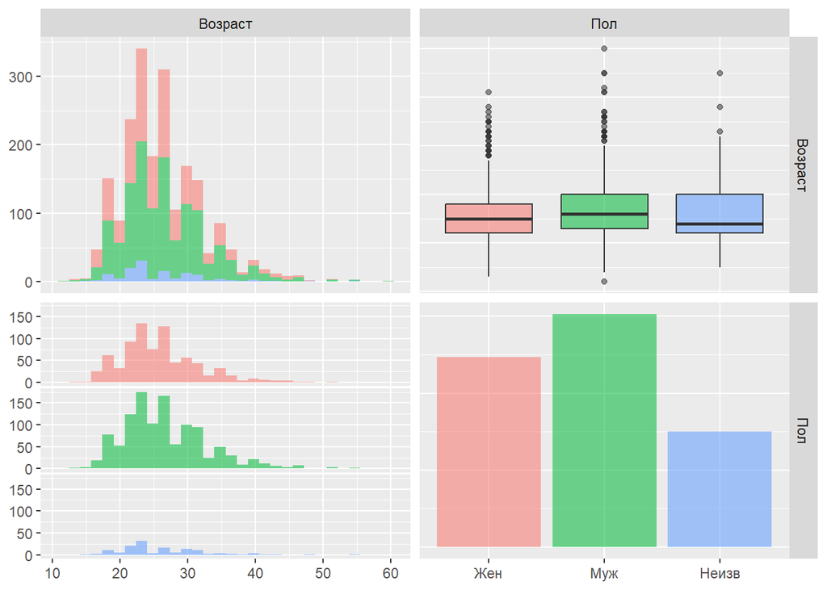

```r
ggpairs(df_names, columns = c(139,138), aes(color = Пол, alpha = 0.5), diag=list(continuous="barDiag"), lower = list(continuous="box_no_facet"))
```

Посмотрим, влияет ли пол протагониста на оценки. Сравним на примере нескольких фильмов: 4. Пятый элемент (муж, 1997) 36. В бой идут одни старики (муж, 1973) 44. Интердевочка (жен, 1989) 51. А зори здесь тихие (жен, 1972)

```r
name_ref
```

| id | names |
| --- | --- |
| 1 | Невероятные приключения итальянцев в России |
| 2 | Телохранитель |
| 3 | Кавказская пленница или Новые приключения Шурика |
| 4 | Пятый элемент |
| 5 | Терминатор |
| 6 | Крепкий орешек |
| 7 | Полицейская академия |
| 8 | Чужие |
| 9 | Крокодил Данди |
| 10 | Здравствуйте, я ваша тетя! |

[output cut: 192 more lines]

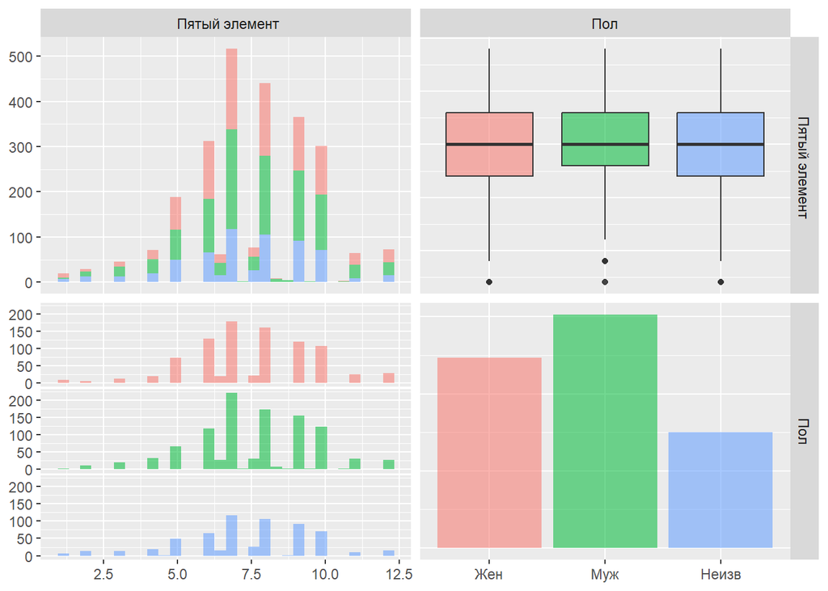

```r
ggpairs(df_names, columns = c(4,138), aes(color = Пол, alpha = 0.5), diag=list(continuous="barDiag"))
```

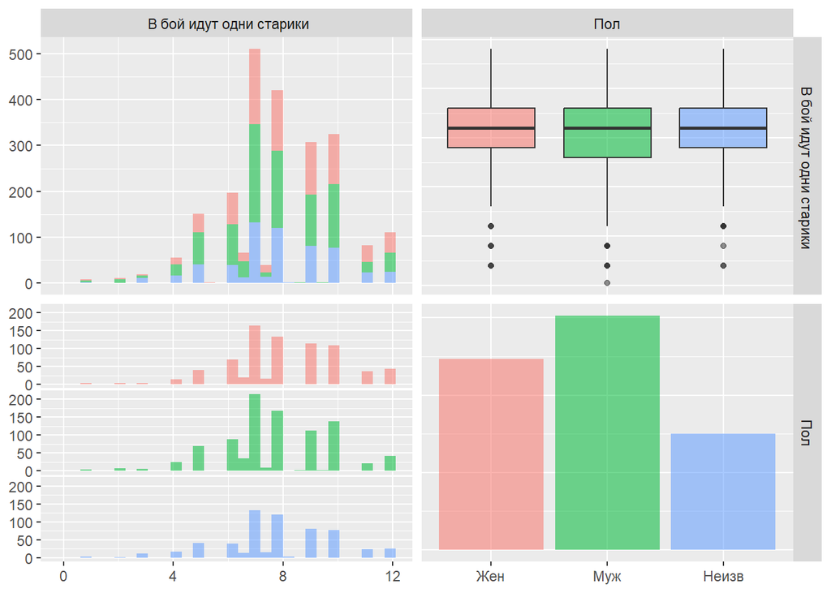

```r
ggpairs(df_names, columns = c(36,138), aes(color = Пол, alpha = 0.5), diag=list(continuous="barDiag"))
```

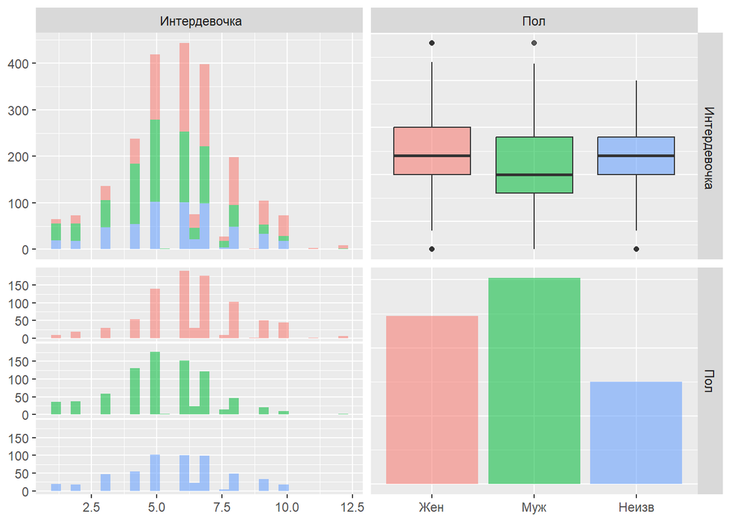

```r
ggpairs(df_names, columns = c(44,138), aes(color = Пол, alpha = 0.5), diag=list(continuous="barDiag"))
```

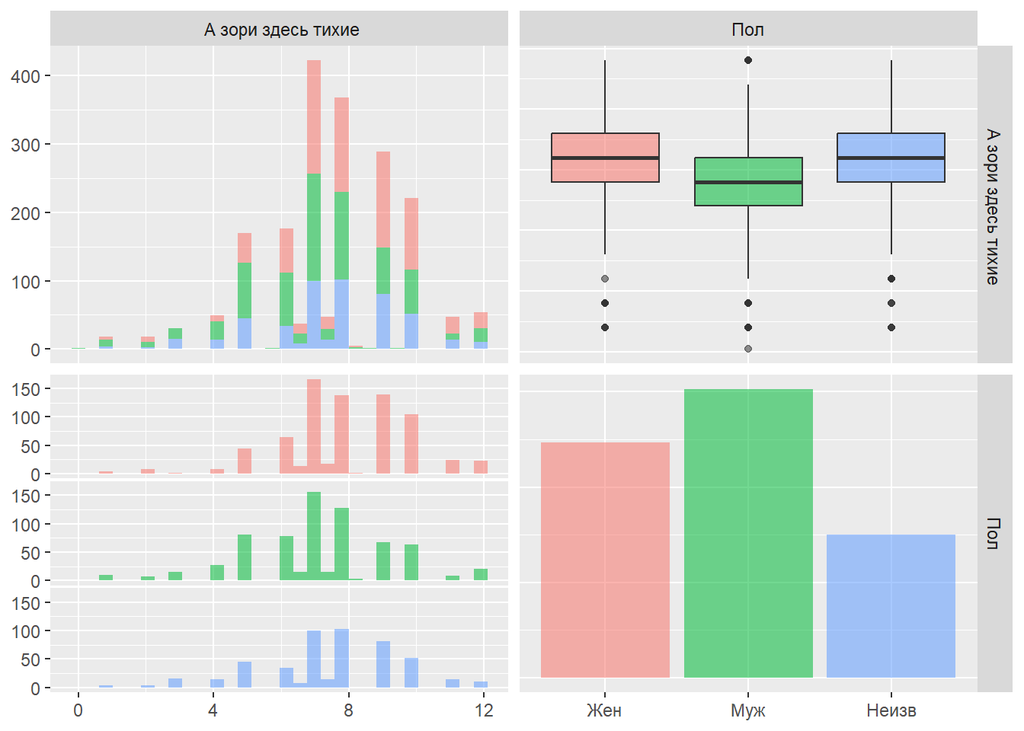

```r
ggpairs(df_names, columns = c(51,138), aes(color = Пол, alpha = 0.5), diag=list(continuous="barDiag"))
```

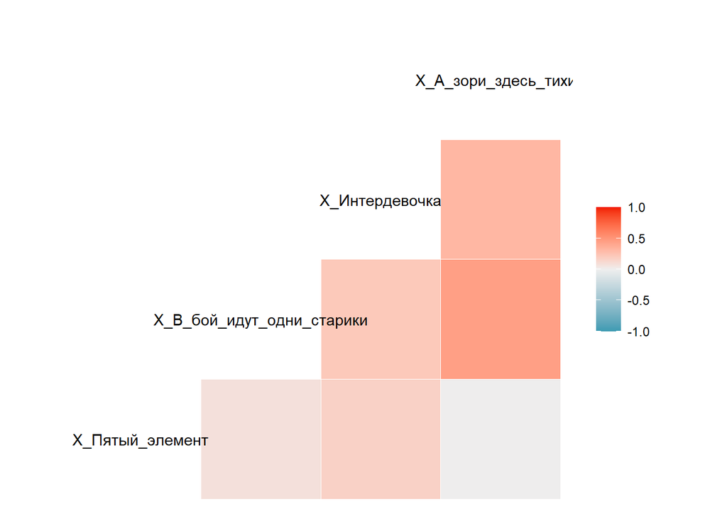

```r
ggcorr(df_names[,c(4,36, 44, 51, 138)])
```

У “А зори здесь тихие” и “Интердевочки” есть различие в оценках: женщины оценивают их лучше, чем мужчины (по медиане). Фильмы, где протагонист - мужчина, имеют почти одинаковую медиану.

# 4. Что-то с оценкой фильмов

Можно ли что-то сказать о человеке по тому, как он оценивает фильмы? Посмотрим на последние признаки (“Нога-ведущая”, “Рука-ведущая” и так далее)

```r
name_ref
```

| id | names |
| --- | --- |
| 1 | Невероятные приключения итальянцев в России |
| 2 | Телохранитель |
| 3 | Кавказская пленница или Новые приключения Шурика |
| 4 | Пятый элемент |
| 5 | Терминатор |
| 6 | Крепкий орешек |
| 7 | Полицейская академия |
| 8 | Чужие |
| 9 | Крокодил Данди |
| 10 | Здравствуйте, я ваша тетя! |

[output cut: 192 more lines]

```r
summary(df_names$`Рука-переплетение пальцев рук - ведущая`)
```

```
##    Min. 1st Qu.  Median    Mean 3rd Qu.    Max.    NA's
##   1.000   1.000   1.000   1.424   2.000   2.000    2628
```

```r
table(df_names$`Рука-переплетение пальцев рук - ведущая`)
```

```
##
##   1   2
## 502 370
```

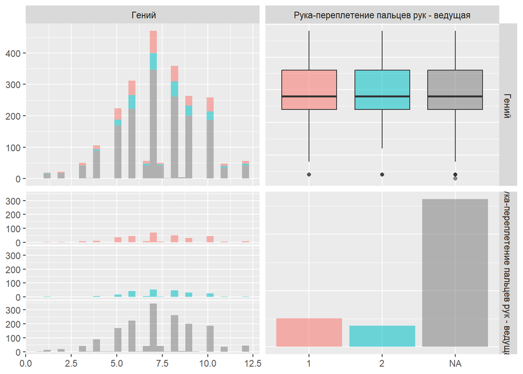

```r
df_misc<-df_names|>mutate(`Рука-переплетение пальцев рук - ведущая` = as.character(`Рука-переплетение пальцев рук - ведущая`))
ggpairs(df_misc, columns = c(30,193), aes(color = `Рука-переплетение пальцев рук - ведущая`, alpha = 0.5), diag=list(continuous="barDiag"))
```

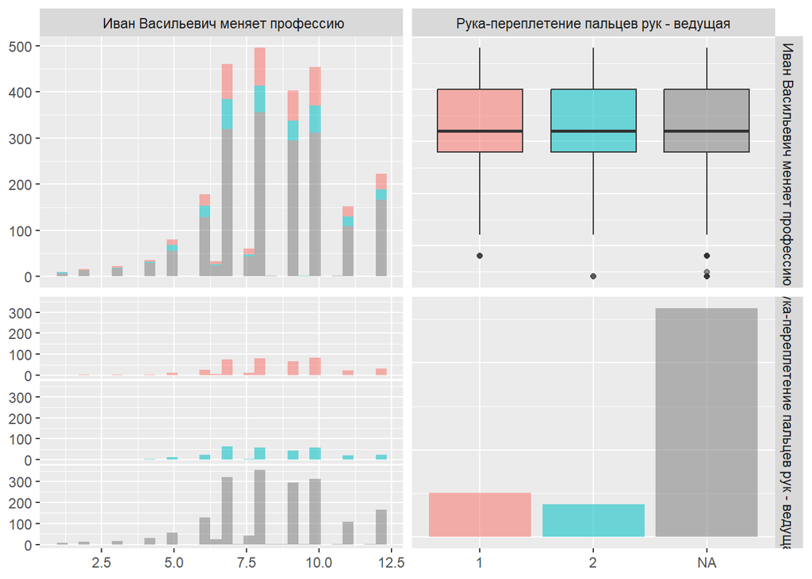

```r
ggpairs(df_misc, columns = c(31,193), aes(color = `Рука-переплетение пальцев рук - ведущая`, alpha = 0.5), diag=list(continuous="barDiag"))
```

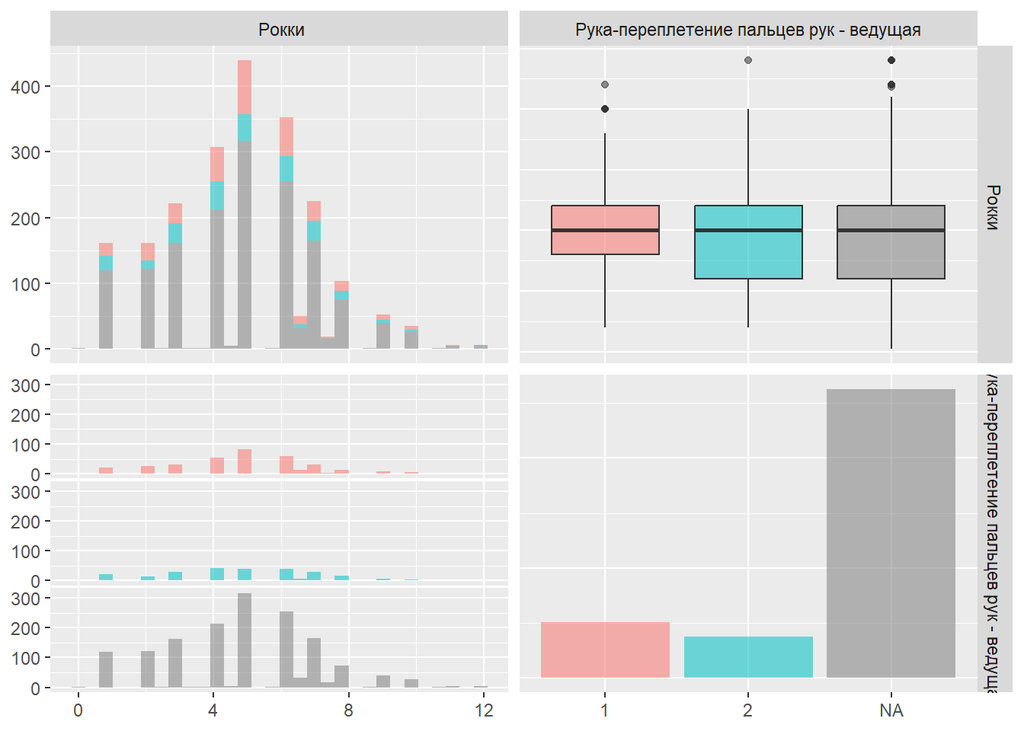

```r
ggpairs(df_misc, columns = c(32,193), aes(color = `Рука-переплетение пальцев рук - ведущая`, alpha = 0.5), diag=list(continuous="barDiag"))
```

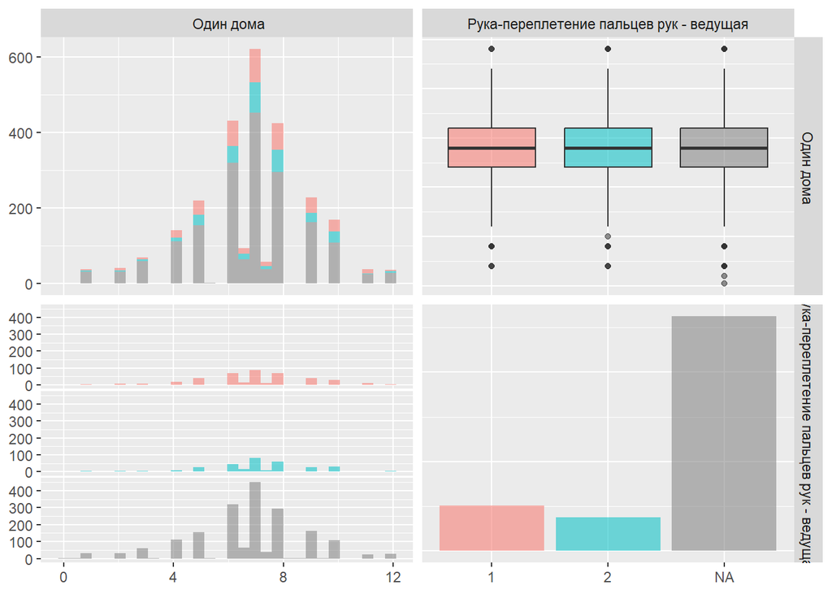

```r
ggpairs(df_misc, columns = c(33,193), aes(color = `Рука-переплетение пальцев рук - ведущая`, alpha = 0.5), diag=list(continuous="barDiag"))
```

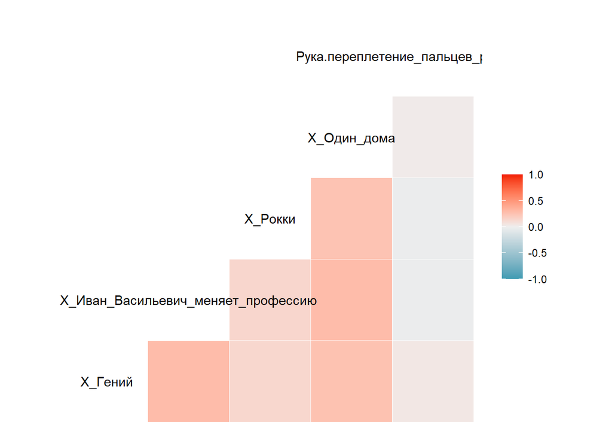

```r
ggcorr(df_names[,c(30:33, 193)])
```

```r
summary(df_names$`Рука-имитация аплодисментов - ведущая`)
```

```
##    Min. 1st Qu.  Median    Mean 3rd Qu.    Max.    NA's
##   1.000   1.000   2.000   1.721   2.000   2.000    2623
```

```r
table(df_names$`Рука-имитация аплодисментов - ведущая`)
```

```
##
##   1   2
## 245 632
```

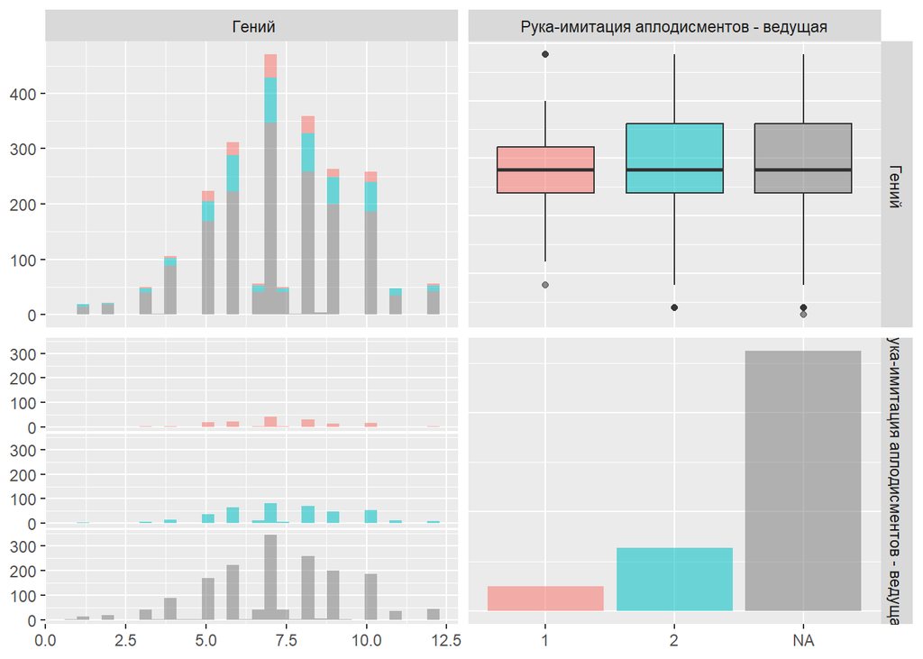

```r
df_misc<-df_misc|>mutate(`Рука-имитация аплодисментов - ведущая` = as.character(`Рука-имитация аплодисментов - ведущая`))
ggpairs(df_misc, columns = c(30,194), aes(color = `Рука-имитация аплодисментов - ведущая`, alpha = 0.5), diag=list(continuous="barDiag"))
```

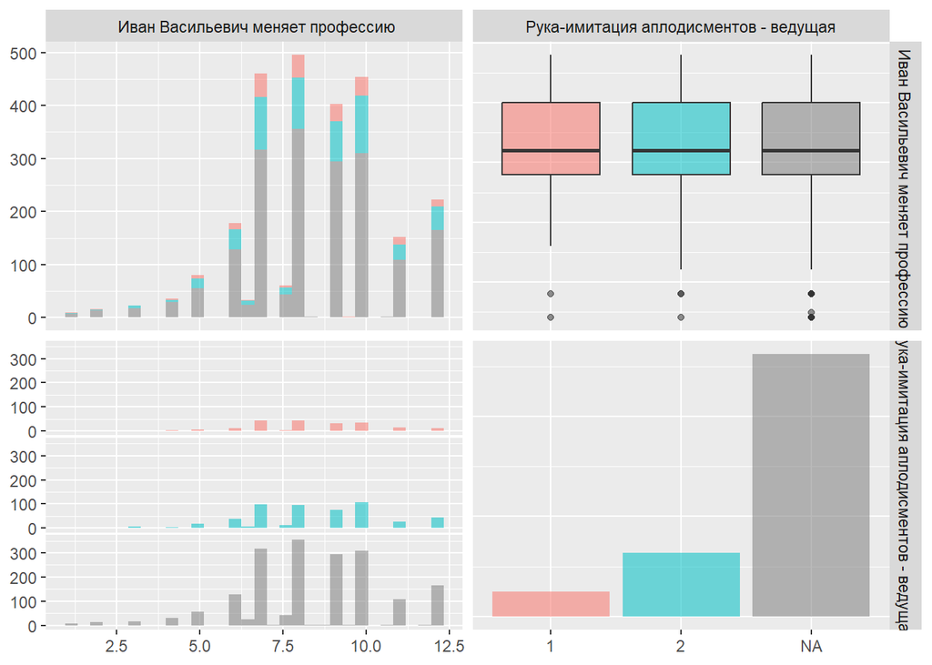

```r
ggpairs(df_misc, columns = c(31,194), aes(color = `Рука-имитация аплодисментов - ведущая`, alpha = 0.5), diag=list(continuous="barDiag"))
```

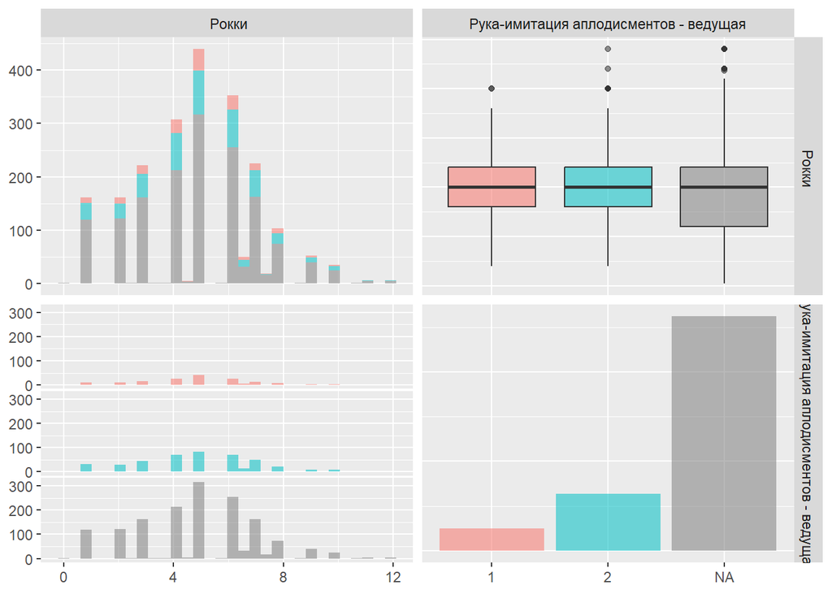

```r
ggpairs(df_misc, columns = c(32,194), aes(color = `Рука-имитация аплодисментов - ведущая`, alpha = 0.5), diag=list(continuous="barDiag"))
```

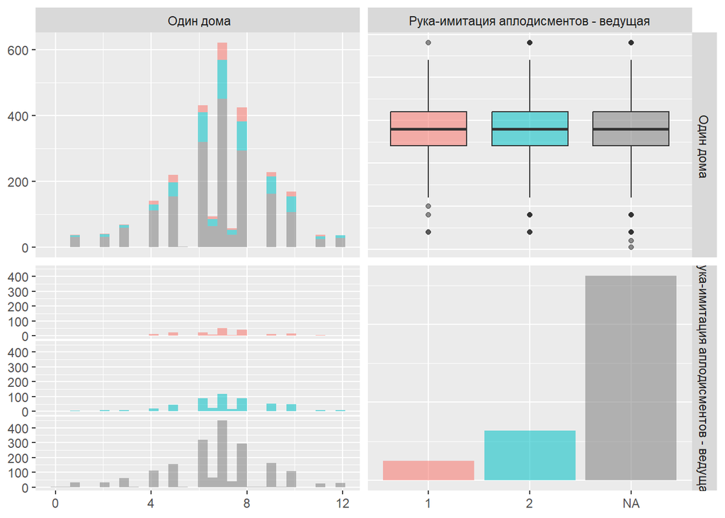

```r
ggpairs(df_misc, columns = c(33,194), aes(color = `Рука-имитация аплодисментов - ведущая`, alpha = 0.5), diag=list(continuous="barDiag"), upper=list(continuous="box_no_facet"))
```

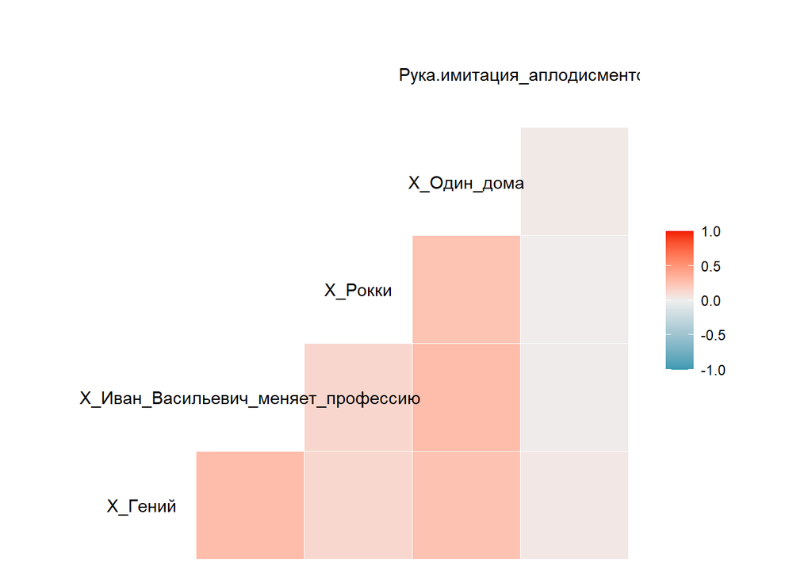

```r
ggcorr(df_names[, c(30:33, 194)])
```